# Reproducible Research: Peer Assessment 1

## Loading and preprocessing the data

We load the data with columns ‘steps’, ‘date’ and ‘interval’

```r
unzip("activity.zip")
activity <- read.csv("activity.csv", colClasses = c("numeric", "Date", "numeric"))
```

## What is the mean total number of steps taken per day?

1. Calculate the total number of steps taken per day

```r
stepsummary <- activity %>% group_by(date) %>% summarise(totalsteps = sum(steps))
head(stepsummary)
```

```
## Source: local data frame [6 x 2]
##
##         date totalsteps
## 1 2012-10-01         NA
## 2 2012-10-02        126
## 3 2012-10-03      11352
## 4 2012-10-04      12116
## 5 2012-10-05      13294
## 6 2012-10-06      15420
```

2. Make a histogram of the total number of steps taken each day

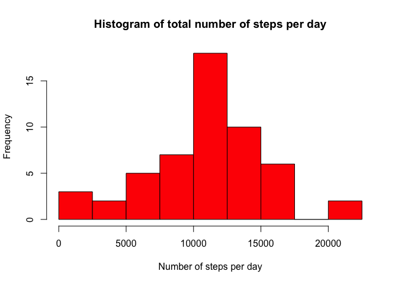

```r
hist(stepsummary$totalsteps,
     breaks = seq(0, 22500, by = 2500),
     main = "Histogram of total number of steps per day",
     xlab = "Number of steps per day",
     col = "red")
```

3. Calculate and report the mean and median of the total number of steps taken per day

```r
mean(stepsummary$totalsteps, na.rm = TRUE)
```

```
## [1] 10766.19
```

```r
median(stepsummary$totalsteps, na.rm = TRUE)
```

```
## [1] 10765
```

## What is the average daily activity pattern?

1. Make a time series plot (i.e. type = “l”) of the 5-minute interval (x-axis) and the average number of steps taken, averaged across all days (y-axis)

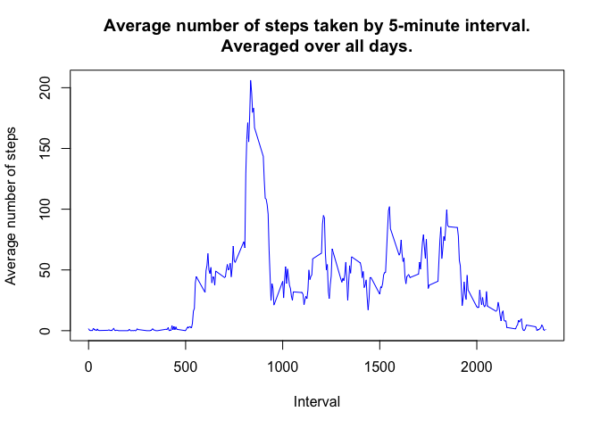

```r
avgsteps <- activity %>% group_by(interval) %>% summarise(average = mean(steps, na.rm = TRUE))
plot(avgsteps,
     type = "l",
     main = "Average number of steps taken by 5-minute interval.\nAveraged over all days.",
     ylab = "Average number of steps",
     xlab = "Interval",
     col = "blue")
```

2. Which 5-minute interval, on average across all the days in the dataset, contains the maximum number of steps?

```r
avgsteps[which.max(avgsteps$average),]
```

```
## Source: local data frame [1 x 2]
##
##   interval  average
## 1      835 206.1698
```

## Imputing missing values

1. Calculate and report the total number of missing values in the dataset (i.e. the total number of rows with NAs)

```r
sum(is.na(activity$steps))
```

```
## [1] 2304
```

2. Devise a strategy for filling in all of the missing values in the dataset For the missing values, we will take the mean of that interval, averaged over all days and rounded to the nearest integer.

```r
roundedavgsteps <- activity %>% group_by(interval) %>% summarise(average = round(mean(steps, na.rm = TRUE)))
```

3. Create a new dataset that is equal to the original dataset but with the missing data filled in.

```r
imputedactivity <- left_join(activity, roundedavgsteps, by = "interval")
imputedactivity[is.na(activity$steps), "steps"] <- imputedactivity[is.na(activity$steps), "average"]
```

Before:

```r
activity[285:295,]
```

```
##     steps       date interval
## 285    NA 2012-10-01     2340
## 286    NA 2012-10-01     2345
## 287    NA 2012-10-01     2350
## 288    NA 2012-10-01     2355
## 289     0 2012-10-02        0
## 290     0 2012-10-02        5
## 291     0 2012-10-02       10
## 292     0 2012-10-02       15
## 293     0 2012-10-02       20
## 294     0 2012-10-02       25
## 295     0 2012-10-02       30
```

After:

```r
imputedactivity[285:295,]
```

```
##     steps       date interval average
## 285     3 2012-10-01     2340       3
## 286     1 2012-10-01     2345       1
## 287     0 2012-10-01     2350       0
## 288     1 2012-10-01     2355       1
## 289     0 2012-10-02        0       2
## 290     0 2012-10-02        5       0
## 291     0 2012-10-02       10       0
## 292     0 2012-10-02       15       0
## 293     0 2012-10-02       20       0
## 294     0 2012-10-02       25       2
## 295     0 2012-10-02       30       1
```

4. Make a histogram of the total number of steps taken each day and Calculate and report the mean and median total number of steps taken per day.

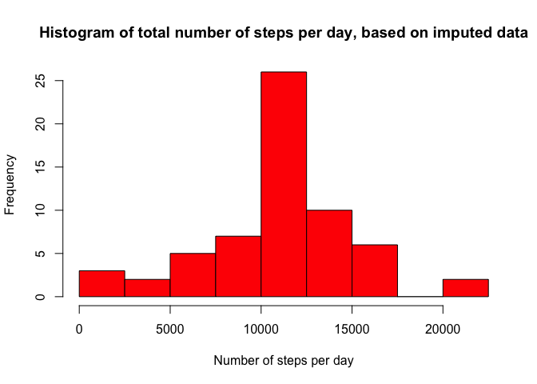

```r
imputedstepsummary <- imputedactivity %>% group_by(date) %>% summarise(totalsteps = sum(steps))
hist(imputedstepsummary$totalsteps,
     breaks = seq(0, 22500, by = 2500),
     main = "Histogram of total number of steps per day, based on imputed data",
     xlab = "Number of steps per day",
     col = "red")
```

```r
mean(imputedstepsummary$totalsteps, na.rm = TRUE)
```

```
## [1] 10765.64
```

```r
median(imputedstepsummary$totalsteps, na.rm = TRUE)
```

```
## [1] 10762
```

These values differ only slightly from the original data with missing values.

## Are there differences in activity patterns between weekdays and weekends?

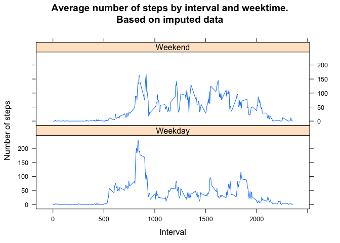

```r
library(lattice)
stepaverages <- imputedactivity %>%
    mutate(weektime = factor(ifelse(weekdays(date) %in% c("Saturday", "Sunday"),
                                    "Weekend",
                                    "Weekday"))) %>%
    group_by(weektime, interval) %>%
    summarise(average = mean(steps))

xyplot(average ~ interval | weektime,
       data = stepaverages,
       layout = 1:2,
       type = "l",
       main = "Average number of steps by interval and weektime.\nBased on imputed data",
       ylab = "Number of steps",
       xlab = "Interval")
```

It seems most activity occurs in the morning around 8:30 AM during the weekdays. In the weekends, the activity is more spreadout over the day and it starts later.